# Projekt - Szereg Czasowy

16 06 2020

**Uczelnia:** Akademia Górniczo-Hutnicza im. Stanisława Staszica w Krakowie

**Wydział:** Wydział Geodezji Górniczej i Inżynierii Środowiska

**Kierunek:** Geoinformacja

**Rok:** drugi

**Semestr:** czwarty

**Przedmiot:** Przetwarzanie Danych Środowiskowych

**Prowadzacy:** dr inż. Mateusz Rzeszutek

**Autorzy:** Miłosz Cygan, Miłosz Jeżyna

# 1. Cel projektu

Celem projektu jest pozyskanie danych środowiskowych z kilku lat w celu przeprowadzenia predykcji. Nasza praca będzie polegała na testowaniu różnych modeli i wyborze tych, które naszym zdaniem wydają się najlepsze, a będzie to możliwe dzięki wiedzy uzyskanej na zajęciach. Analiza jak i predykcja będzie prowadzona dla miasta Poznań

# 2. Wczytanie pakietów i pozyskanie danych

## 2.1 Wczytanie potrzebnych pakietów

```r
library(worldmet)
library(lubridate)
library(tidyverse)
library(giosimport)
library(purrr)
library(stringr)
library(dplyr)
library(openair)
library(gridExtra)
library(devtools)
library(seasonal)
library(seasonalview)
library(gridExtra)
library(feasts)
library(lubridate)
library(fpp3)
library(GGally)
library(car)
```

## 2.2 Pozyskanie danych z NOAA

```r
data <- importNOAA(code = '123300-99999', year = 2012:2020)
```

## 2.3 Pozyskanie danych z GIOŚ

Zgodnie z [giosimport-dokumntacja](https://rpubs.com/rzeszut/giosimport)

# 3. Scalenie i miesięczne uśrednienie danych

```r
dane_f <- daneGIOS
dane_f <- left_join(dane_f, daneNOAA, by = "date")

dane_f <- dane_f %>% na.omit() %>%
  select(date, obs, ws, air_temp, dew_point, atmos_pres, RH, visibility)

dane_m <- dane_f %>% timeAverage(avg.time = "month")


dane_m <- dane_m %>%
  mutate(date = yearmonth(date)) %>%
  as_tsibble(index = date)

dane_m <- dane_m %>%  rename(pm10 = obs)

dane <- dane_m
```

| date | pm10 | ws | air_temp | dew_point | atmos_pres | RH | visibility |
| --- | --- | --- | --- | --- | --- | --- | --- |
| 2012 sty | 29.79117 | 4.646667 | 1.244955 | -0.2227928 | 1015.009 | 90.55462 | 9517.081 |
| 2012 lut | 64.69627 | 3.989545 | -1.888716 | -3.9375776 | 1022.593 | 86.63643 | 6866.693 |
| 2012 mar | 40.93042 | 5.024410 | 7.011321 | 3.4873821 | 1021.790 | 80.49054 | 10598.585 |
| 2012 kwi | 28.99626 | 4.521945 | 7.945511 | 2.0061097 | 1005.330 | 70.39579 | 11320.617 |
| 2012 maj | 19.75080 | 4.027316 | 15.803674 | 7.5626198 | 1015.538 | 61.42381 | 14802.923 |
| 2012 cze | 16.28252 | 3.681935 | 16.381119 | 10.3018648 | 1012.349 | 70.06968 | 13879.324 |

# 4. Wydzielenie treningowego i testowego zbioru danych

```r
treningowy <- dane_m %>% filter(year(date) <= 2019)

testowy <- dane_m %>% filter(year(date) == 2020)
```

# 5. Budowa modeli

## 5.1 Macierze Korelacji

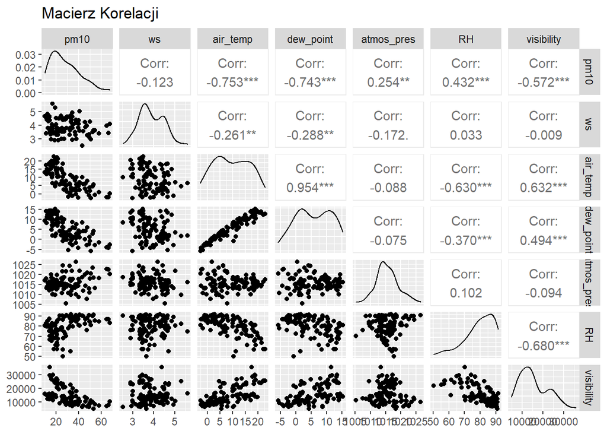

```r
dane_m %>%
  GGally::ggpairs(columns = 2:ncol(.), title = "Macierz Korelacji")
```

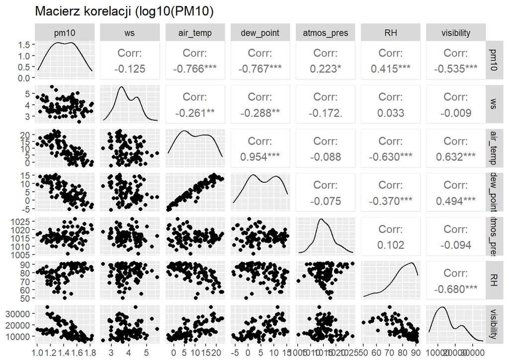

```r
dane_m %>% mutate(pm10 = log10(pm10)) %>%
  GGally::ggpairs(columns = 2:ncol(.), title =  "Macierz korelacji (log10(PM10)")
```

Najadziej korelującymi zmiennymi z PM10 są Temperatura, Temperatura Punktu Rosy i Widoczność. Później użyjemy ich jako predyktory do tworzenia modeli. Ponadto Temperatura i Temperatura Punktu Rosy wysoko korelują między sobą, co oznacza że jeśli jednocześnie użyjemy do modelowania, może wystąpić autokorelacja reszt.

W drugiej macierzy zastosowanie log10 pozwoliło na zwiększenie korelacji o setne części.

## 5.2 Wykres opóźnień

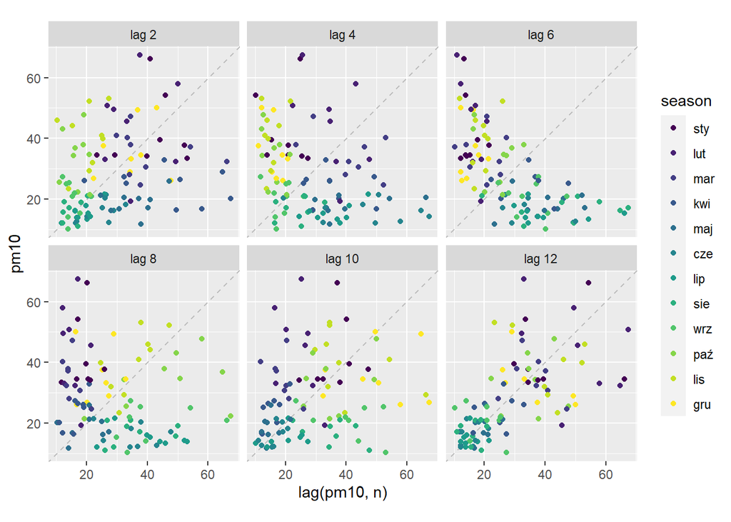

```r
dane_m %>% gg_lag(geom = "point", lags = seq(2,12,2))
```

Patrząc na wykres lag12 możemy stwierdzić, że w naszym zbiorze danych występuje sezonowość. Jeden sezon to okres jednego roku. Wynika to z tego, że nasze dane uśrednione są miesięcznie, a rok ma 12 miesięcy

## 5.3 Wykres opóźnień predyktrów

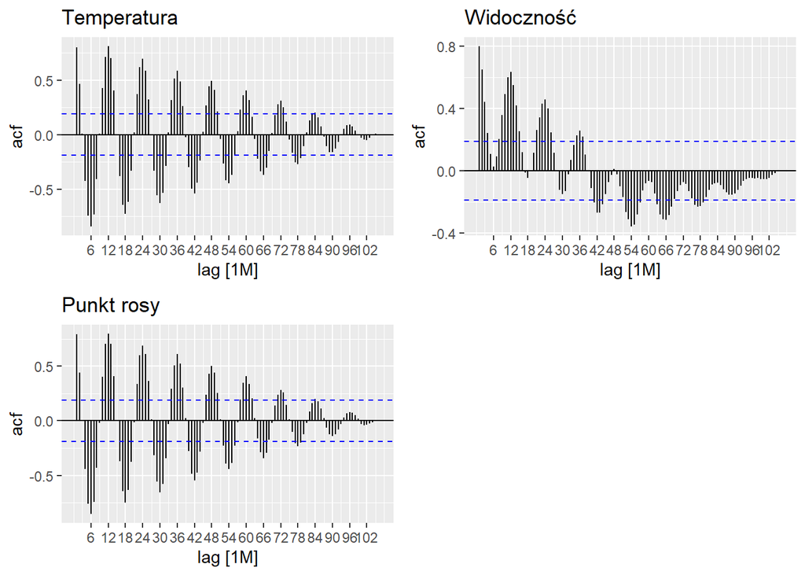

```r
grid.arrange(
             dane_m %>% ACF(air_temp, lag_max = 12*10) %>% autoplot() + ggtitle("Temperatura"),
             dane_m %>% ACF(visibility, lag_max = 12*10) %>% autoplot() + ggtitle("Widoczność"),
             dane_m %>% ACF(dew_point, lag_max = 12*10) %>% autoplot() + ggtitle ("Punkt rosy"),
             ncol =2)
```

## 5.4 Regresja liniowa prosta

```r
sd <- sd(dane_m$pm10)

list(mod1 = pm10 ~ air_temp,
     mod2 = pm10 ~ visibility,
     mod3 = pm10 ~ dew_point,
     mod4 = log(pm10) ~ air_temp,
     mod5 = log(pm10) ~ visibility,
     mod6 = log(pm10) ~ dew_point,
     mod7 = log10(pm10) ~ air_temp,
     mod8 = log10(pm10) ~ visibility,
     mod9 = log10(pm10) ~ dew_point,
     mod10 = pm10^2 ~ air_temp,
     mod11 = pm10^2 ~ visibility,
     mod12 = pm10^2 ~ dew_point,
     mod13 = pm10/sd ~ air_temp,
     mod14 = pm10/sd ~ visibility,
     mod15 = pm10/sd ~ dew_point) -> modele_proste

map(modele_proste, as.formula)  -> modele_proste


proste <- map(.x = modele_proste,
            .f = ~model(treningowy, TSLM(formula = .x)) %>% glance()) %>%
  do.call(rbind, .) %>%
  select(.model, adj_r_squared, CV, AIC, AICc, BIC)

proste %>%
  mutate(.model = modele_proste) %>%
  arrange(AIC) %>%
  knitr::kable(digits = 2)
```

| .model | adj_r_squared | CV | AIC | AICc | BIC |
| --- | --- | --- | --- | --- | --- |
| log10(pm10) ~ dew_point | 0.62 | 0.02 | -389.42 | -389.16 | -381.73 |
| log10(pm10) ~ air_temp | 0.60 | 0.02 | -385.54 | -385.28 | -377.84 |
| log10(pm10) ~ visibility | 0.27 | 0.03 | -327.28 | -327.02 | -319.59 |
| log(pm10) ~ dew_point | 0.62 | 0.09 | -229.29 | -229.03 | -221.60 |
| log(pm10) ~ air_temp | 0.60 | 0.09 | -225.40 | -225.14 | -217.71 |
| log(pm10) ~ visibility | 0.27 | 0.17 | -167.14 | -166.88 | -159.45 |
| pm10/sd ~ dew_point | 0.58 | 0.46 | -72.51 | -72.25 | -64.81 |
| pm10/sd ~ air_temp | 0.58 | 0.46 | -72.47 | -72.21 | -64.78 |
| pm10/sd ~ visibility | 0.30 | 0.76 | -23.46 | -23.20 | -15.77 |
| pm10 ~ dew_point | 0.58 | 82.51 | 425.44 | 425.70 | 433.13 |
| pm10 ~ air_temp | 0.58 | 82.63 | 425.47 | 425.74 | 433.17 |
| pm10 ~ visibility | 0.30 | 136.33 | 474.48 | 474.74 | 482.17 |
| pm10^2 ~ air_temp | 0.49 | 504528.32 | 1261.64 | 1261.90 | 1269.33 |
| pm10^2 ~ dew_point | 0.49 | 509069.79 | 1262.45 | 1262.71 | 1270.14 |
| pm10^2 ~ visibility | 0.28 | 703324.77 | 1294.67 | 1294.93 | 1302.36 |

## 5.5 Regresja wieloraka

```r
list(mod1 = pm10 ~ air_temp + visibility,
     mod2 = pm10 ~ air_temp + dew_point,
     mod3 = pm10 ~ visibility + dew_point,
     mod4 = log(pm10) ~ air_temp + visibility,
     mod5 = log(pm10) ~ air_temp + dew_point,
     mod6 = log(pm10) ~ visibility + dew_point,
     mod7 = log10(pm10) ~ air_temp + visibility,
     mod8 = log10(pm10) ~ air_temp + dew_point,
     mod9 = log10(pm10) ~ visibility + dew_point,
     mod10 = pm10^2 ~ air_temp + visibility,
     mod11 = pm10^2 ~ air_temp + dew_point,
     mod12 = pm10^2 ~ visibility + dew_point,
     mod13 = pm10/sd ~ air_temp + visibility,
     mod14 = pm10/sd ~ air_temp + dew_point,
     mod15 = pm10/sd ~ visibility + dew_point,
     mod16 = pm10 ~ air_temp + visibility + dew_point,
     mod17 = log(pm10) ~ air_temp + visibility + dew_point,
     mod18 = log10(pm10) ~ air_temp + visibility + dew_point,
     mod19 = pm10^2 ~ air_temp + visibility + dew_point,
     mod20 = pm10/sd ~ air_temp + visibility + dew_point) -> wielorakie

map(wielorakie, as.formula)  -> wielorakie

wielorakie_m <- map(.x = wielorakie,
              .f = ~model(treningowy, TSLM(formula = .x)) %>% glance()) %>%
  do.call(rbind, .) %>%
  select(.model, adj_r_squared, CV, AIC, AICc, BIC)

wielorakie_m %>%
  mutate(.model = wielorakie) %>%
  arrange(AIC) %>%
  knitr::kable(digits = 2)
```

| .model | adj_r_squared | CV | AIC | AICc | BIC |
| --- | --- | --- | --- | --- | --- |
| log10(pm10) ~ visibility + dew_point | 0.63 | 0.02 | -391.73 | -391.29 | -381.47 |
| log10(pm10) ~ air_temp + visibility + dew_point | 0.62 | 0.02 | -389.74 | -389.08 | -376.92 |
| log10(pm10) ~ air_temp + dew_point | 0.62 | 0.02 | -388.75 | -388.31 | -378.49 |
| log10(pm10) ~ air_temp + visibility | 0.60 | 0.02 | -383.74 | -383.30 | -373.48 |
| log(pm10) ~ visibility + dew_point | 0.63 | 0.09 | -231.60 | -231.16 | -221.34 |
| log(pm10) ~ air_temp + visibility + dew_point | 0.62 | 0.09 | -229.61 | -228.94 | -216.79 |
| log(pm10) ~ air_temp + dew_point | 0.62 | 0.09 | -228.61 | -228.17 | -218.35 |
| log(pm10) ~ air_temp + visibility | 0.60 | 0.09 | -223.60 | -223.16 | -213.35 |
| pm10/sd ~ visibility + dew_point | 0.61 | 0.43 | -78.34 | -77.90 | -68.08 |
| pm10/sd ~ air_temp + visibility + dew_point | 0.60 | 0.44 | -76.34 | -75.67 | -63.52 |
| pm10/sd ~ air_temp + dew_point | 0.59 | 0.46 | -73.12 | -72.68 | -62.86 |
| pm10/sd ~ air_temp + visibility | 0.58 | 0.46 | -71.99 | -71.55 | -61.74 |
| pm10 ~ visibility + dew_point | 0.61 | 77.37 | 419.61 | 420.04 | 429.86 |
| pm10 ~ air_temp + visibility + dew_point | 0.60 | 78.33 | 421.60 | 422.27 | 434.42 |
| pm10 ~ air_temp + dew_point | 0.59 | 81.55 | 424.83 | 425.27 | 435.08 |
| pm10 ~ air_temp + visibility | 0.58 | 82.50 | 425.95 | 426.39 | 436.21 |
| pm10^2 ~ visibility + dew_point | 0.52 | 476478.84 | 1256.72 | 1257.16 | 1266.98 |
| pm10^2 ~ air_temp + visibility + dew_point | 0.52 | 481538.67 | 1258.68 | 1259.35 | 1271.50 |
| pm10^2 ~ air_temp + visibility | 0.50 | 498398.42 | 1261.38 | 1261.82 | 1271.64 |
| pm10^2 ~ air_temp + dew_point | 0.49 | 502854.84 | 1262.21 | 1262.65 | 1272.47 |

## 5.6 Regresja wieloraka z trendem i sezonowością

```r
list(mod41 = pm10 ~ air_temp + visibility + trend() + season(),
     mod42 = pm10 ~ air_temp + dew_point + trend() + season(),
     mod43 = pm10 ~ visibility + dew_point + trend() + season(),
     mod44 = log(pm10) ~ air_temp + visibility + trend() + season(),
     mod45 = log(pm10) ~ air_temp + dew_point + trend() + season(),
     mod46 = log(pm10) ~ visibility + dew_point + trend() + season(),
     mod47 = log10(pm10) ~ air_temp + visibility + trend() + season(),
     mod48 = log10(pm10) ~ air_temp + dew_point + trend() + season(),
     mod49 = log10(pm10) ~ visibility + dew_point + trend() + season(),
     mod50 = pm10^2 ~ air_temp + visibility + trend() + season(),
     mod51 = pm10^2 ~ air_temp + dew_point + trend() + season(),
     mod52 = pm10^2 ~ visibility + dew_point + trend() + season(),
     mod53 = pm10/sd ~ air_temp + visibility + trend() + season(),
     mod54 = pm10/sd ~ air_temp + dew_point + trend() + season(),
     mod55 = pm10/sd ~ visibility + dew_point + trend() + season(),
     mod56 = pm10 ~ air_temp + visibility + dew_point + trend() + season(),
     mod57 = log(pm10) ~ air_temp + visibility + dew_point + trend() + season(),
     mod58 = log10(pm10) ~ air_temp + visibility + dew_point + trend() + season(),
     mod59 = pm10^2 ~ air_temp + visibility + dew_point + trend() + season(),
     mod60 = pm10/sd ~ air_temp + visibility + dew_point + trend(),
     mod99 = log10(pm10) ~ air_temp + trend() + season(),
     mod98 = log10(pm10) ~ air_temp + season()) -> wieloraka_sezon_trend

map(wieloraka_sezon_trend, as.formula)  -> wieloraka_sezon_trend

wieorakiest <- map(.x = wieloraka_sezon_trend,
              .f = ~model(treningowy, TSLM(formula = .x)) %>% glance()) %>%
  do.call(rbind, .) %>%
  select(.model, adj_r_squared, CV, AIC, AICc, BIC)

tabela <- wieorakiest %>%
  mutate(.model = wieloraka_sezon_trend) %>%
  arrange(AIC) %>%
  knitr::kable(digits = 2)

tabela
```

| .model | adj_r_squared | CV | AIC | AICc | BIC |
| --- | --- | --- | --- | --- | --- |
| log10(pm10) ~ air_temp + visibility + dew_point + trend() + season() | 0.79 | 0.01 | -434.73 | -426.88 | -391.14 |
| log10(pm10) ~ air_temp + dew_point + trend() + season() | 0.76 | 0.01 | -424.56 | -417.68 | -383.53 |
| log10(pm10) ~ visibility + dew_point + trend() + season() | 0.74 | 0.01 | -415.92 | -409.03 | -374.89 |
| log10(pm10) ~ air_temp + visibility + trend() + season() | 0.73 | 0.01 | -412.21 | -405.32 | -371.18 |
| log10(pm10) ~ air_temp + trend() + season() | 0.72 | 0.01 | -410.61 | -404.61 | -372.14 |
| log10(pm10) ~ air_temp + season() | 0.72 | 0.01 | -410.50 | -405.31 | -374.60 |
| log(pm10) ~ air_temp + visibility + dew_point + trend() + season() | 0.79 | 0.06 | -274.60 | -266.75 | -231.00 |
| log(pm10) ~ air_temp + dew_point + trend() + season() | 0.76 | 0.06 | -264.43 | -257.54 | -223.40 |
| log(pm10) ~ visibility + dew_point + trend() + season() | 0.74 | 0.07 | -255.79 | -248.90 | -214.76 |
| log(pm10) ~ air_temp + visibility + trend() + season() | 0.73 | 0.07 | -252.07 | -245.19 | -211.04 |
| pm10/sd ~ visibility + dew_point + trend() + season() | 0.71 | 0.37 | -96.78 | -89.89 | -55.75 |
| pm10/sd ~ air_temp + dew_point + trend() + season() | 0.70 | 0.38 | -93.51 | -86.63 | -52.48 |
| pm10/sd ~ air_temp + visibility + dew_point + trend() | 0.67 | 0.38 | -92.47 | -91.52 | -77.08 |
| pm10/sd ~ air_temp + visibility + trend() + season() | 0.68 | 0.40 | -87.08 | -80.19 | -46.05 |
| pm10 ~ air_temp + visibility + dew_point + trend() + season() | 0.74 | 60.97 | 392.80 | 400.65 | 436.39 |
| pm10 ~ visibility + dew_point + trend() + season() | 0.71 | 66.36 | 401.16 | 408.05 | 442.19 |
| pm10 ~ air_temp + dew_point + trend() + season() | 0.70 | 67.59 | 404.43 | 411.31 | 445.46 |
| pm10 ~ air_temp + visibility + trend() + season() | 0.68 | 72.30 | 410.86 | 417.75 | 451.89 |
| pm10^2 ~ air_temp + visibility + dew_point + trend() + season() | 0.63 | 427192.40 | 1242.81 | 1250.65 | 1286.40 |
| pm10^2 ~ visibility + dew_point + trend() + season() | 0.62 | 438694.61 | 1244.83 | 1251.72 | 1285.86 |
| pm10^2 ~ air_temp + dew_point + trend() + season() | 0.59 | 460951.96 | 1251.73 | 1258.61 | 1292.76 |
| pm10^2 ~ air_temp + visibility + trend() + season() | 0.58 | 476762.41 | 1254.85 | 1261.73 | 1295.88 |

## 5.7 Wybór najelpszych modeli regresji

Najlepiej wypadają modele, w których wartość PM10 została zlogarytmowana dzięsiętnie.

Z utworzonych wyżej modeli wybraliśmy 6, którym chcemy się bliżej przyjrzeć

model1 = log10(pm10) ~ air_temp + visibility + trend() + season()  
model2 = log10(pm10) ~ air_temp + dew_point + trend() + season()  
model3 = log10(pm10) ~ visibility + dew_point + trend() + season()  
model4 = log10(pm10) ~ air_temp + dew_point  
model5 = log10(pm10) ~ dew_point  
model6 = log10(pm10) ~ air_temp + trend() + season()

```r
model1 = log10(pm10) ~ air_temp + visibility + trend() + season()
model2 = log10(pm10) ~ air_temp + dew_point + trend() + season()
model3 = log10(pm10) ~ visibility + dew_point + trend() + season()
model4 = log10(pm10) ~ air_temp + dew_point
model5 = log10(pm10) ~ dew_point
model6 = log10(pm10) ~ air_temp + trend() + season()

wybrany1 <- model(treningowy, TSLM(model1))
wybrany2 <- model(treningowy, TSLM(model2))
wybrany3 <- model(treningowy, TSLM(model3))
wybrany4 <- model(treningowy, TSLM(model4))
wybrany5 <- model(treningowy, TSLM(model5))
wybrany6 <- model(treningowy, TSLM(model6))
```

### 5.7.1 Model1 log10(pm10) ~ air_temp + visibility + trend() + season()

```r
shapiro.test(wybrany1 %>% residuals() %>% pull(.resid))
```

```
##
##  Shapiro-Wilk normality test
##
## data:  wybrany1 %>% residuals() %>% pull(.resid)
## W = 0.98515, p-value = 0.3537
```

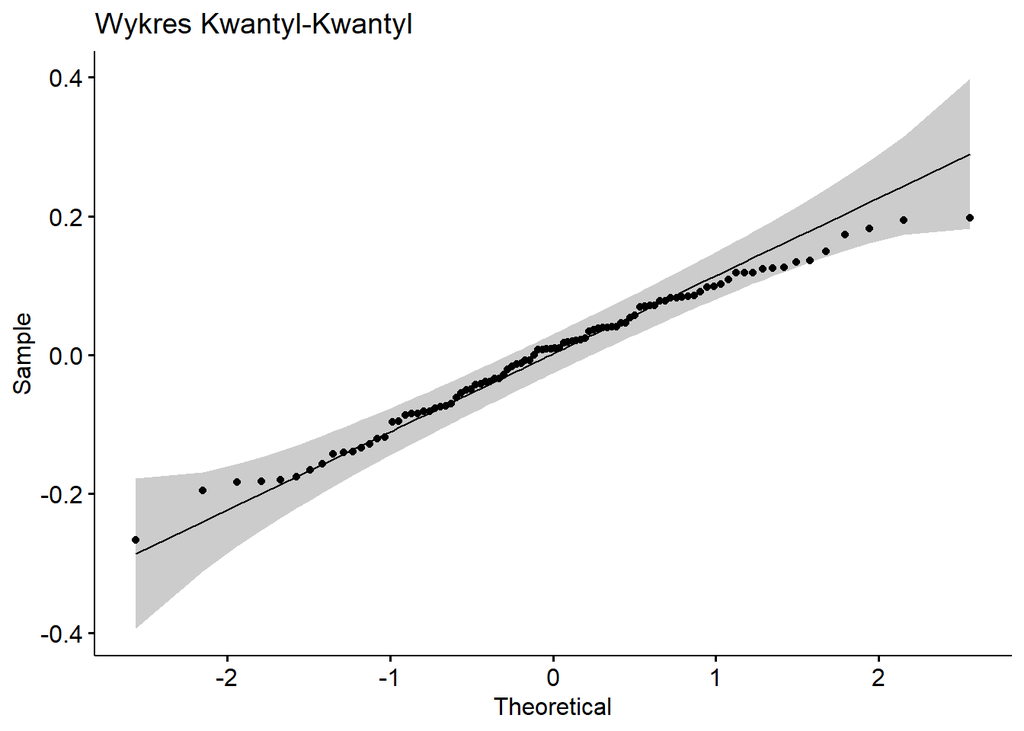

```r
ggpubr::ggqqplot(wybrany1 %>% residuals() %>%  pull(.resid), main = "Wykres Kwantyl-Kwantyl")
```

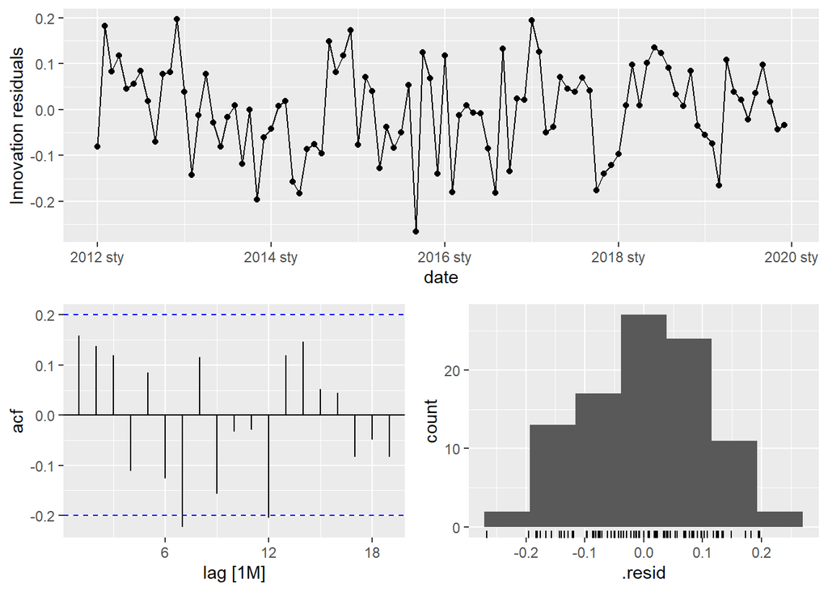

```r
gg_tsresiduals(wybrany1)
```

```r
durbinWatsonTest(wybrany1 %>% residuals() %>% pull(.resid))
```

```
## [1] 1.673261
```

Wariancja reszt niejednorodna. Rozkład przejawia cechy rozkładu normalnego. Występuje autokorelacja dodatnia.

### 5.7.2 Model2 log10(pm10) ~ air_temp + dew_point + trend() + season()

```r
shapiro.test(wybrany2 %>% residuals() %>% pull(.resid))  ###NORMALNOŚĆ ROZKŁADU
```

```
##
##  Shapiro-Wilk normality test
##
## data:  wybrany2 %>% residuals() %>% pull(.resid)
## W = 0.99025, p-value = 0.7108
```

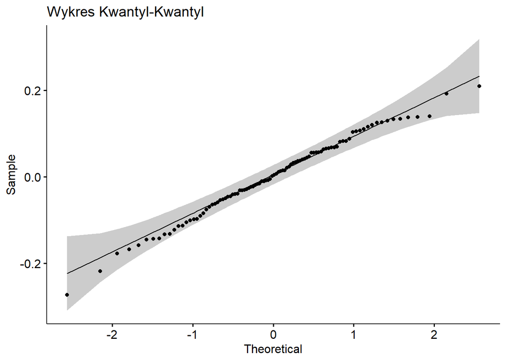

```r
ggpubr::ggqqplot(wybrany2 %>% residuals() %>%  pull(.resid), main = "Wykres Kwantyl-Kwantyl")
```

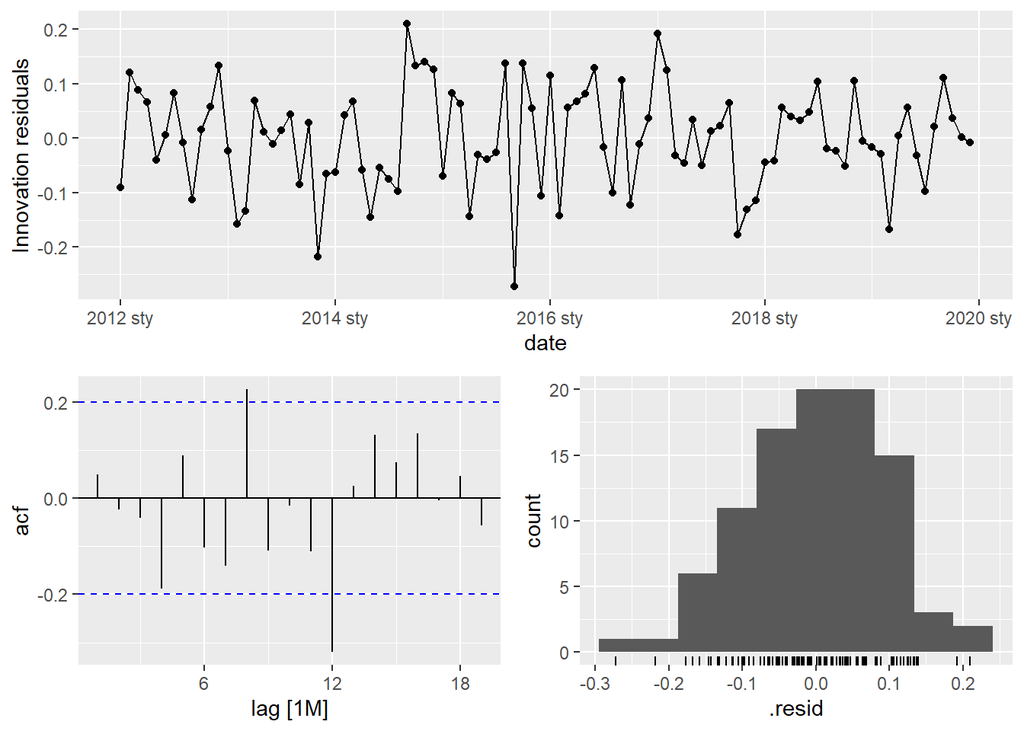

```r
gg_tsresiduals(wybrany2)
```

```r
durbinWatsonTest(wybrany2 %>% residuals() %>% pull(.resid))
```

```
## [1] 1.891419
```

Wariancja reszt niejednorodna. Rozkład przejawia cechy rozkładu normalnego. Występuje autokorelacja dodatnia.

### 5.7.3 Model3 log10(pm10) ~ visibility + dew_point + trend() + season()

```r
shapiro.test(wybrany3 %>% residuals() %>% pull(.resid))  ###NORMALNOŚĆ ROZKŁADU
```

```
##
##  Shapiro-Wilk normality test
##
## data:  wybrany3 %>% residuals() %>% pull(.resid)
## W = 0.96745, p-value = 0.01731
```

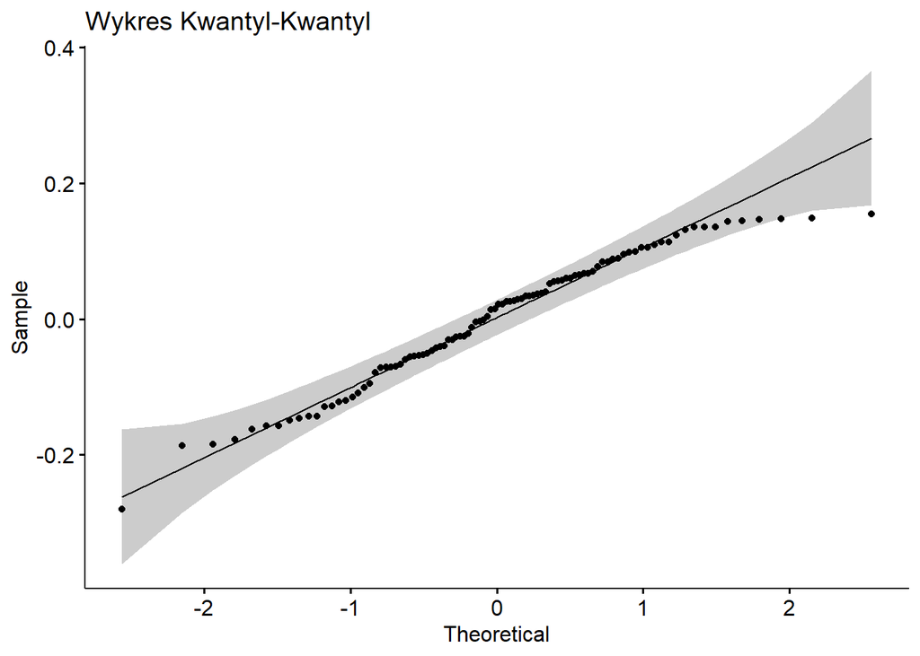

```r
ggpubr::ggqqplot(wybrany3 %>% residuals() %>%  pull(.resid), main = "Wykres Kwantyl-Kwantyl")
```

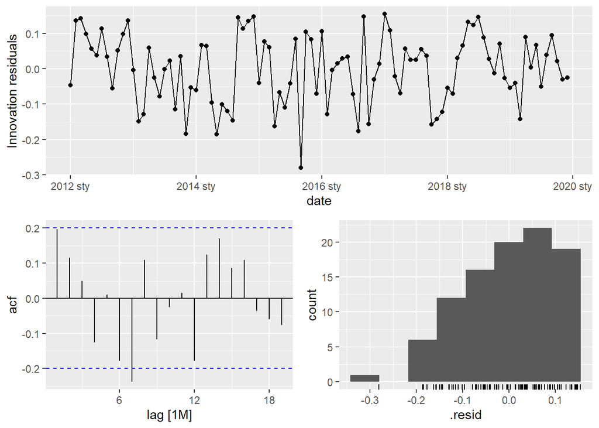

```r
gg_tsresiduals(wybrany3)
```

```r
durbinWatsonTest(wybrany3 %>% residuals() %>% pull(.resid))
```

```
## [1] 1.604071
```

Wariancja reszt niejednorodna. Rozkład nie przejawia cech rozkładu normalnego. Występuje autokorelacja dodatnia.

### 5.7.4 Model4 log10(pm10) ~ air_temp + dew_point

```r
shapiro.test(wybrany4 %>% residuals() %>% pull(.resid))  ###NORMALNOŚĆ ROZKŁADU
```

```
##
##  Shapiro-Wilk normality test
##
## data:  wybrany4 %>% residuals() %>% pull(.resid)
## W = 0.9899, p-value = 0.6836
```

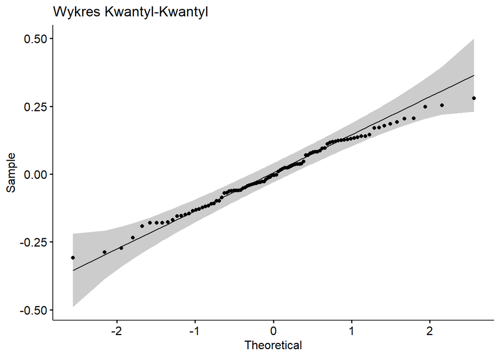

```r
ggpubr::ggqqplot(wybrany4 %>% residuals() %>%  pull(.resid), main = "Wykres Kwantyl-Kwantyl")
```

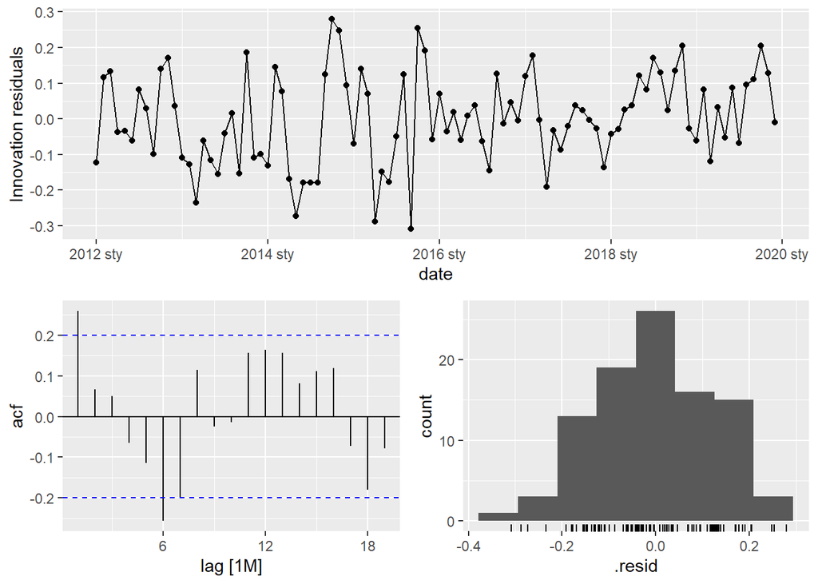

```r
gg_tsresiduals(wybrany4)
```

```r
durbinWatsonTest(wybrany4 %>% residuals() %>% pull(.resid))
```

```
## [1] 1.471874
```

Wariancja reszt niejednorodna. Rozkład przejawia cechy rozkładu normalnego. Występuje autokorelacja dodatnia.

### 5.7.5 Model5 log10(pm10) ~ dew_point

```r
shapiro.test(wybrany5 %>% residuals() %>% pull(.resid))  ###NORMALNOŚĆ ROZKŁADU
```

```
##
##  Shapiro-Wilk normality test
##
## data:  wybrany5 %>% residuals() %>% pull(.resid)
## W = 0.99283, p-value = 0.8919
```

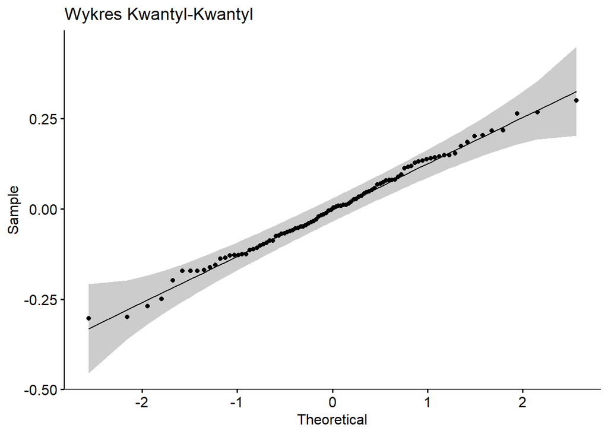

```r
ggpubr::ggqqplot(wybrany5 %>% residuals() %>%  pull(.resid), main = "Wykres Kwantyl-Kwantyl")
```

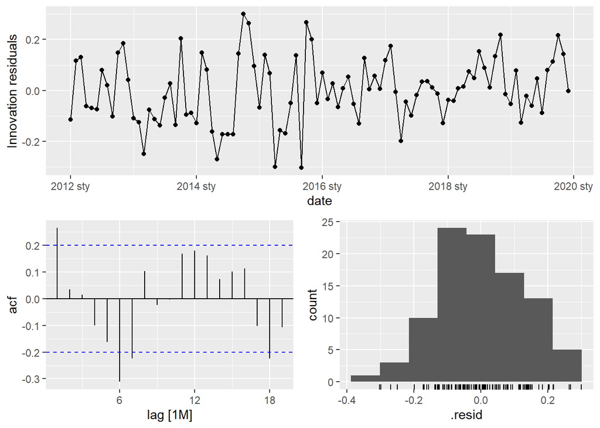

```r
gg_tsresiduals(wybrany5)
```

```r
durbinWatsonTest(wybrany5 %>% residuals() %>% pull(.resid))
```

```
## [1] 1.462349
```

Wariancja reszt niejednorodna. Rozkład przejawia cechy rozkładu normalnego. Występuje autokorelacja dodatnia.

### 5.7.6 Model6 log10(pm10) ~ air_temp + trend() + season()

```r
shapiro.test(wybrany6 %>% residuals() %>% pull(.resid))  ###NORMALNOŚĆ ROZKŁADU
```

```
##
##  Shapiro-Wilk normality test
##
## data:  wybrany6 %>% residuals() %>% pull(.resid)
## W = 0.98777, p-value = 0.5215
```

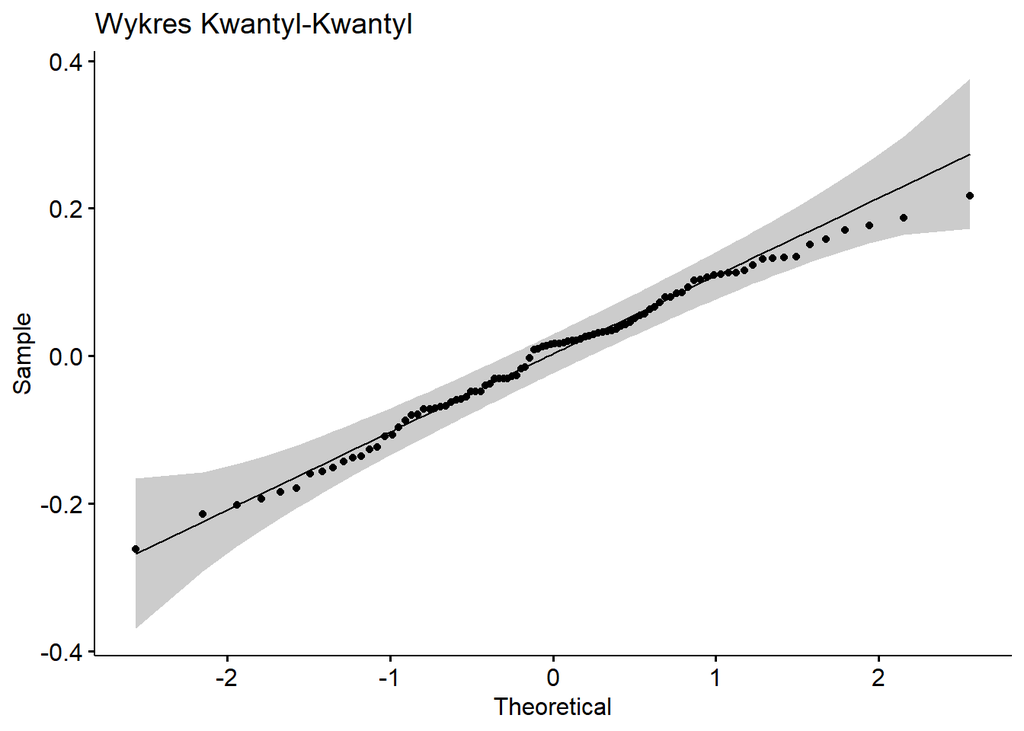

```r
ggpubr::ggqqplot(wybrany6 %>% residuals() %>%  pull(.resid), main = "Wykres Kwantyl-Kwantyl")
```

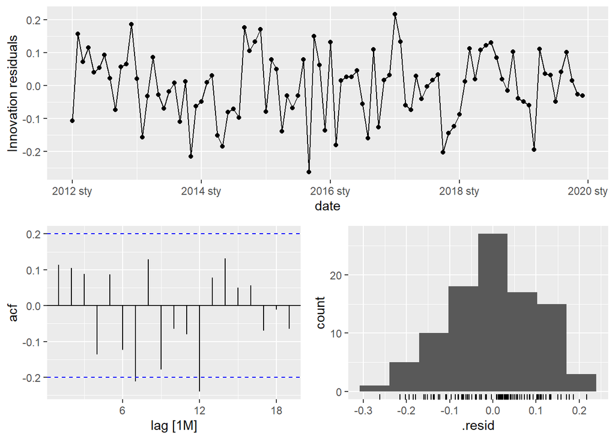

```r
gg_tsresiduals(wybrany6)
```

```r
durbinWatsonTest(wybrany6 %>% residuals() %>% pull(.resid))
```

```
## [1] 1.760895
```

Wariancja reszt niejednorodna. Rozkład przejawia cechy rozkładu normalnego. Występuje autokorelacja dodatnia.